# Q4

## a)

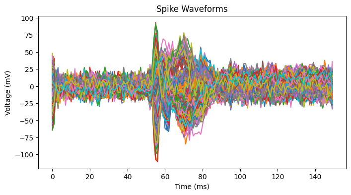

There are specific jumps in the data between times 50 and 90 that go above or below about 40mV. These jumps look alike in shape. I can figure out the number of nerve cells by looking at each set of data and grouping them by their unique patterns. Then, I can sort these nerve cells by the groups of jumps they make. Look at the second picture that shows the same jump patterns in 3 different times.

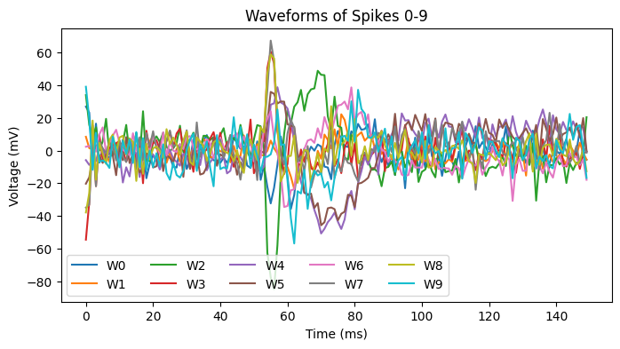

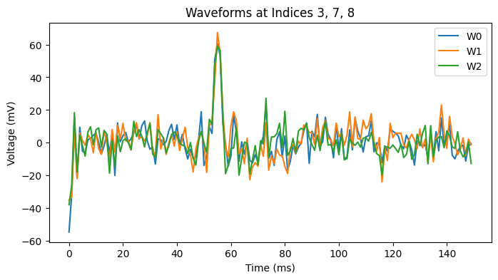

## b)

[figure not shown]

Interpretation: The graph shows a quick drop at the start and then slows down, which is normal for this kind of data. The count of these drops matches the total data points we looked at, which is 150.

## c)

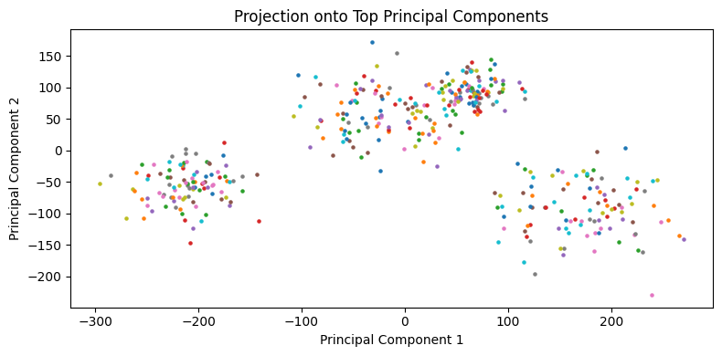

Description: From the main parts of the data, I can see three separate groups. So, there are probably three different nerve cells that gave us the 400 sets of data.

## d)

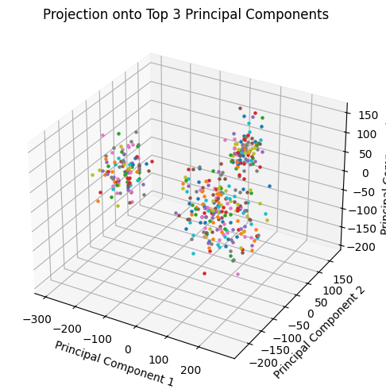

Response: I don't see big changes compared to the 2D picture. There are still three groups, so just like before, Drs. Bell and Zell probably studied three different nerve cells.